# Plotting Directly with Matplotlib

## What I'm Doing

In this lab I created and customized line, scatter, bar, histogram, pie, and subplot visualizations with Matplotlib using Canadian immigration data (1980–2013)

## 1. Setting Up

I imported NumPy, Pandas, and Matplotlib, then enabled the inline backend to render plots in the notebook.

```
import numpy as np
import pandas as pd

# Use the inline backend to generate plots within the notebook
%matplotlib inline
import matplotlib as mpl
import matplotlib.pyplot as plt
```

## 2. Getting to Know the Dataset

The dataset covers international migration flows to Canada from 1980 to 2013, sourced from the United Nations. I fetch it directly from a hosted URL using `requests` and load it into a Pandas DataFrame.

```
import requests
import io

# Define the URL
URL = "https://cf-courses-data.s3.us.cloud-object-storage.appdomain.cloud/IBMDeveloperSkillsNetwork-DV0101EN-SkillsNetwork/Data%20Files/Canada.csv"

# Send a GET request to the URL
response = requests.get(URL)

# Convert the content into a BytesIO object
text = io.BytesIO(response.content)

# Read the CSV data into a pandas dataframe
df_can = pd.read_csv(text)
```

Preview data:

```
df_can.head()
```

|  | Country | Continent | Region | DevName | 1980 | 1981 | 1982 | 1983 | 1984 | 1985 | ... | 2005 | 2006 | 2007 | 2008 | 2009 | 2010 | 2011 | 2012 | 2013 | Total |
| --- | --- | --- | --- | --- | --- | --- | --- | --- | --- | --- | --- | --- | --- | --- | --- | --- | --- | --- | --- | --- | --- |
| 0 | Afghanistan | Asia | Southern Asia | Developing regions | 16 | 39 | 39 | 47 | 71 | 340 | ... | 3436 | 3009 | 2652 | 2111 | 1746 | 1758 | 2203 | 2635 | 2004 | 58639 |
| 1 | Albania | Europe | Southern Europe | Developed regions | 1 | 0 | 0 | 0 | 0 | 0 | ... | 1223 | 856 | 702 | 560 | 716 | 561 | 539 | 620 | 603 | 15699 |
| 2 | Algeria | Africa | Northern Africa | Developing regions | 80 | 67 | 71 | 69 | 63 | 44 | ... | 3626 | 4807 | 3623 | 4005 | 5393 | 4752 | 4325 | 3774 | 4331 | 69439 |
| 3 | American Samoa | Oceania | Polynesia | Developing regions | 0 | 1 | 0 | 0 | 0 | 0 | ... | 0 | 1 | 0 | 0 | 0 | 0 | 0 | 0 | 0 | 6 |
| 4 | Andorra | Europe | Southern Europe | Developed regions | 0 | 0 | 0 | 0 | 0 | 0 | ... | 0 | 1 | 1 | 0 | 0 | 0 | 0 | 1 | 1 | 15 |

5 rows × 39 columns

Checking data dimenions:

```
print(df_can.shape)
```

```
(195, 39)
```

**195 rows** (countries) and **39 columns** (country metadata + yearly immigration data from 1980 to 2013, plus a total column).

## 3. Cleaning the Data

I set the **Country** column as the index so I can easily look up countries using the `.loc` accessor.

```
df_can.set_index('Country', inplace=True)
df_can.head()
```

| Country | Continent | Region | DevName | 1980 | 1981 | 1982 | 1983 | 1984 | 1985 | 1986 | ... | 2005 | 2006 | 2007 | 2008 | 2009 | 2010 | 2011 | 2012 | 2013 | Total |
| --- | --- | --- | --- | --- | --- | --- | --- | --- | --- | --- | --- | --- | --- | --- | --- | --- | --- | --- | --- | --- | --- |
| Afghanistan | Asia | Southern Asia | Developing regions | 16 | 39 | 39 | 47 | 71 | 340 | 496 | ... | 3436 | 3009 | 2652 | 2111 | 1746 | 1758 | 2203 | 2635 | 2004 | 58639 |
| Albania | Europe | Southern Europe | Developed regions | 1 | 0 | 0 | 0 | 0 | 0 | 1 | ... | 1223 | 856 | 702 | 560 | 716 | 561 | 539 | 620 | 603 | 15699 |
| Algeria | Africa | Northern Africa | Developing regions | 80 | 67 | 71 | 69 | 63 | 44 | 69 | ... | 3626 | 4807 | 3623 | 4005 | 5393 | 4752 | 4325 | 3774 | 4331 | 69439 |
| American Samoa | Oceania | Polynesia | Developing regions | 0 | 1 | 0 | 0 | 0 | 0 | 0 | ... | 0 | 1 | 0 | 0 | 0 | 0 | 0 | 0 | 0 | 6 |
| Andorra | Europe | Southern Europe | Developed regions | 0 | 0 | 0 | 0 | 0 | 0 | 2 | ... | 0 | 1 | 1 | 0 | 0 | 0 | 0 | 1 | 1 | 15 |

5 rows × 38 columns

Notice now the country names now serve as indices. Let's confirm the shape and create a helper list of years for plotting.

```
print('data dimensions:', df_can.shape)

# Create a list of years from 1980 - 2013 as strings
years = list(map(str, range(1980, 2014)))
```

```
data dimensions: (195, 38)
```

## 4. Line Plot

A **line plot** shows the **relationship between two continuous variables over an interval**. I'll visualize the total immigration trend to Canada from 1980 to 2013.

First, I compute the yearly total immigrants by summing across all countries.

```
# Create df with only years columns from 1980 - 2013
df_line = df_can[years]

# Apply sum to get total immigrants year-wise
total_immigrants = df_line.sum()
total_immigrants
```

```
1980     99137
1981    110563
1982    104271
1983     75550
1984     73417
dtype: int64
```

Now let's plot this with Matplotlib.

```
fig, ax = plt.subplots()# Create figure and axes
ax.plot(total_immigrants)# Plot the line

# Setting up the Title
ax.set_title('Immigrants between 1980 to 2013')
# Setting up the Labels
ax.set_xlabel('Years')
ax.set_ylabel('Total Immigrants')
plt.show()
```

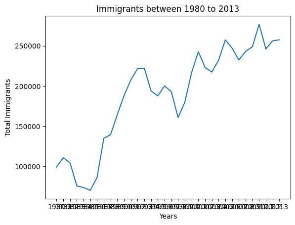

**Result:** Line plot showing immigration trend from 1980 to 2013

The x-axis shows the index (years), and the y-axis shows the total immigrant count. However, **the year labels didn't display cleanly** because the **index values are strings**. Let's **convert them to integers**.

```
# Create figure and axes
fig, ax = plt.subplots()

# Changing the index type to integer
total_immigrants.index = total_immigrants.index.map(int)

# Plot the line
ax.plot(total_immigrants)

ax.set_title('Immigrants between 1980 to 2013')
ax.set_xlabel('Years')
ax.set_ylabel('Total Immigrants')
plt.show()
```

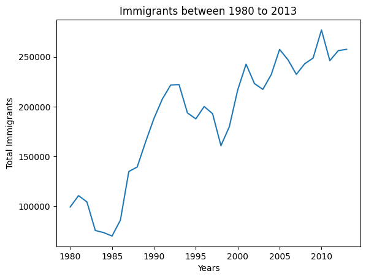

**Result:** Line plot with integer-indexed years

Much better. Now let's **customize the appearance** with markers, color, and line style.

```
fig, ax = plt.subplots() # Create figure and axes

# Changing the index type to integer
total_immigrants.index = total_immigrants.index.map(int)

# Customizing the appearance of Plot
ax.plot(total_immigrants,
        marker='s',          # Square markers
        markersize=5,        # Size of markers
        color='green',       # Line color
        linestyle="dotted")  # Dotted line style

# Setting up the Title
ax.set_title('Immigrants between 1980 to 2013')
ax.set_xlabel('Years')
ax.set_ylabel('Total Immigrants')
ax.legend(['Immigrants'])
plt.show()
```

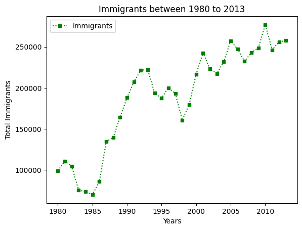

**Result:** Customized line plot with green dotted line and square markers

Let's **add a grid**, a **legend**, and **adjust the axis limits**.

```
fig, ax = plt.subplots() # Create figure and axes

# Plot the line
ax.plot(total_immigrants,
        marker='s',
        markersize=5,
        color='green',
        linestyle="dotted")

# Setting up the Title
ax.set_title('Immigrants between 1980 to 2013')
ax.set_xlabel('Years')
ax.set_ylabel('Total Immigrants')

plt.xlim(1975, 2015) # Limits on x-axis
plt.grid(True) # Enabling Grid
plt.legend(["Immigrants"]) # Legend
plt.show()
```

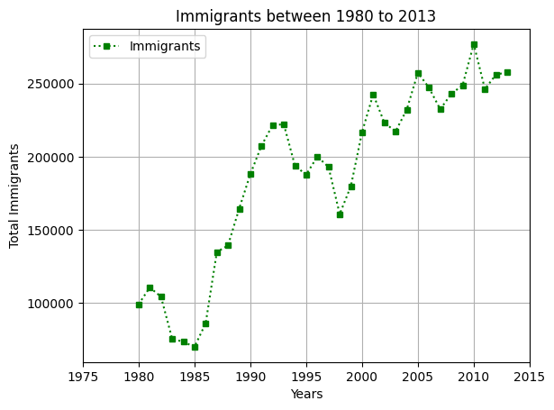

**Result:** Final customized line plot with grid, legend, and adjusted x-limits

### Exercise: Immigration from Haiti

In 2010, Haiti suffered a catastrophic magnitude 7.0 earthquake. Let's visualize how Canada's humanitarian response affected immigration from Haiti.

```
# Creating data for plotting
df_can.reset_index(inplace=True)
haiti = df_can[df_can['Country'] == 'Haiti']

# Creating haiti with only years columns from 1980 - 2013
# and transposing to get the result as a series
haiti = haiti[years].T

# Converting the index to type integer
haiti.index = haiti.index.map(int)

# Plotting the line plot on the data
fig, ax = plt.subplots()
ax.plot(haiti)

# Setting up the Title
ax.set_title('Immigrants from Haiti between 1980 to 2013')
ax.set_xlabel('Years')
ax.set_ylabel('Number of Immigrants')

# Legend
plt.legend(["Immigrants"])
plt.show()
```

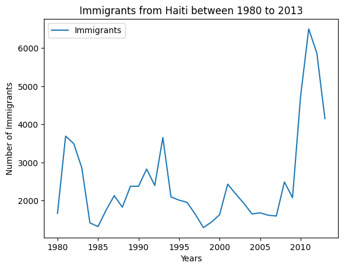

**Result:** Line plot of immigration from Haiti from 1980 to 2013

The spike after 2010 is clear - Canada stepped up refugee acceptance. Let's annotate this point.

```
fig, ax = plt.subplots()

ax.plot(haiti)

ax.set_title('Immigrants from Haiti between 1980 to 2013')
ax.set_xlabel('Years')
# Alternative
#ax.set_xticks(list(range(n, m, s)))
#ax.set_xticks(list(range(1980, 2015, 5)))
ax.set_ylabel('Number of Immigrants')

plt.legend(["Immigrants"])
ax.annotate('2010 Earthquake', xy=(2000, 6000))
plt.show()
```

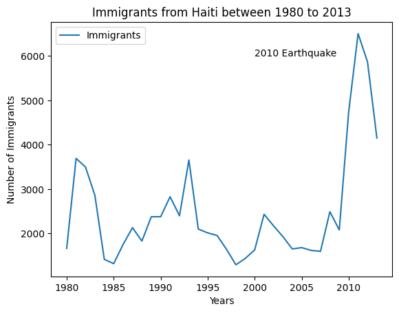

**Result:** Line plot with annotation marking the 2010 Earthquake

## 5. Scatter Plot

A scatter plot **displays individual data points to reveal patterns between two continuous variables**. Let's create one for the same total immigration data.

```
fig, ax = plt.subplots(figsize=(8, 4))

total_immigrants.index = total_immigrants.index.map(int)

# Customizing Scatter Plot
ax.scatter(total_immigrants.index, total_immigrants,
           marker='o',         # Circle markers
           s=20,               # Marker size
           color='darkblue')   # Marker color

plt.title('Immigrants between 1980 to 2013')
plt.xlabel('Years')
plt.ylabel('Total Immigrants')
plt.grid(True)

# Legend at upper center of the figure
ax.legend(["Immigrants"], loc='upper center')
plt.show()
```

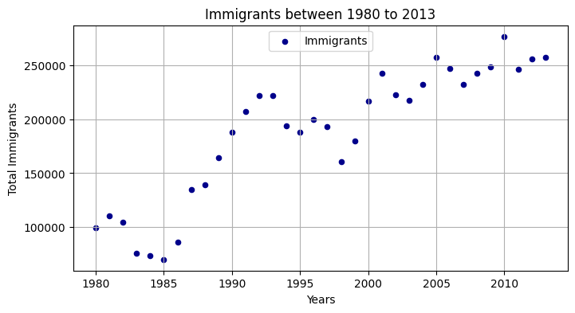

**Result:** Scatter plot showing immigration trend with dark blue dots

Each dot represents the total number of immigrants for a given year. The upward trend over time is clearly visible.

[More markers variation](https://matplotlib.org/stable/api/markers_api.html)

```
# Scatter plot with star markers
ax.scatter(total_immigrants.index, total_immigrants,
           marker='*',    # star shape
           s=100,         # bigger size for visibility
           color='purple')# playful color
```

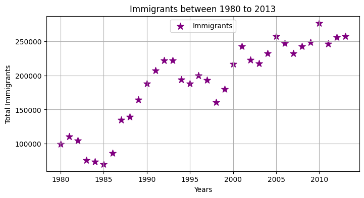

**Result:** Using stars as markers bigger size.

## 6. Bar Plot

A bar plot uses **rectangular bars** to compare values across categories. Let's look at the **top 5 countries that contributed the most immigrants** to Canada from 1980 to 2013.

```
# Sorting the dataframe on 'Total' in descending order
df_can.sort_values(['Total'], ascending=False, axis=0, inplace=True)

# Get the top 5 entries with head function
df_top5 = df_can.head()

# Resetting the index
df_bar_5 = df_top5.reset_index()

# Creating a list of names of the top 5 countries
label = list(df_bar_5.Country)
label
```

```
['India',
 'China',
 'United Kingdom of Great Britain and Northern Ireland',
 'Philippines',
 'Pakistan']
```

The third country name is too long. Let's shorten it.

```
label[2] = 'UK & North Ireland'
label
```

```
['India', 'China', 'UK & North Ireland', 'Philippines', 'Pakistan']
```

Now let's plot the bar chart.

```
fig, ax = plt.subplots(figsize=(10, 4))

ax.bar(label, df_bar_5['Total'], label=label)
ax.set_title('Immigration Trend of Top 5 Countries')
ax.set_ylabel('Number of Immigrants')
ax.set_xlabel('Years')
plt.show()
```

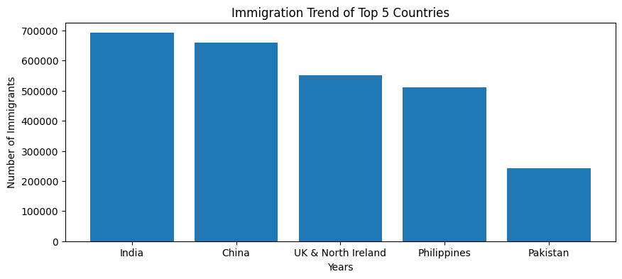

**Result:** Bar plot showing top 5 countries by total immigration

### Exercise: Bottom 5 Countries

Now let's create a bar plot for the **5 countries that contributed the *least* to immigration**.

```
# Sorting the dataframe on 'Total' in ascending order
df_can.sort_values(['Total'], ascending=True, axis=0, inplace=True)

# Get the top 5 entries with head function
df_least5 = df_can.head()

# Resetting the index
df_least5_bar = df_least5.reset_index()

# Creating a list of names of the top 5 countries
label = list(df_least5_bar.Country)

fig, ax = plt.subplots(figsize=(10, 4))

ax.bar(label, df_least5_bar['Total'], label=label)
ax.set_title('Immigration Trend of Bottom 5 Countries')
ax.set_ylabel('Number of Immigrants')
ax.set_xlabel('Years')
plt.show()
```

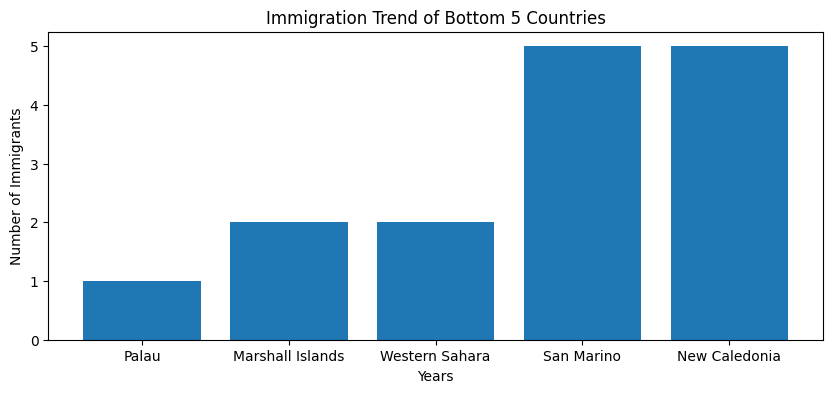

**Result:** Bar plot showing bottom 5 countries by total immigration

## 7. Histogram

A histogram shows the **frequency distribution of a numeric variable by grouping data into bins**. Let's see how many countries fell into each immigration range in **2013**.

```
df_country = df_can.groupby(['Country'])['2013'].sum().reset_index()

fig, ax = plt.subplots(figsize=(10, 4))
ax.hist(df_country['2013'])
ax.set_title('New Immigrants in 2013')
ax.set_xlabel('Number of Immigrants')
ax.set_ylabel('Number of Countries')
ax.legend(['Immigrants'])
plt.show()
```

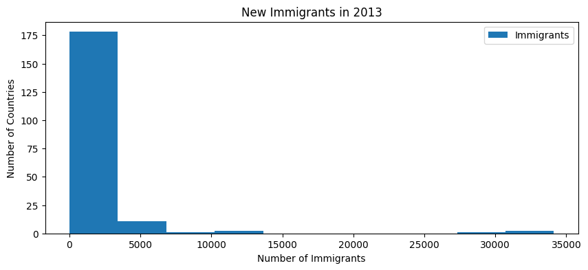

**Result:** Histogram of **new immigrants in 2013**

By **default**, Matplotlib splits the data into **10 bins**. Let's inspect the bin edges and counts, then use them as x-tick labels.

```
# Plot the bar
fig, ax = plt.subplots(figsize=(10, 4))
count = ax.hist(df_country['2013'])

ax.set_title('New Immigrants in 2013')
ax.set_xlabel('Number of Immigrants')
ax.set_ylabel('Number of Countries')
ax.set_xticks(list(map(int, count[1])))
ax.legend(['Immigrants'])
plt.show()
```

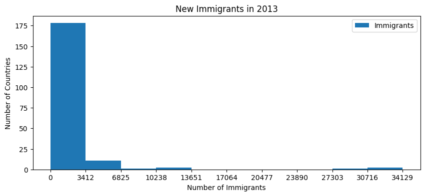

**Result:** Histogram with **bin edges as x-tick labels**

We can also **plot multiple histograms** together. Here I compare the immigration distributions for **Denmark, Norway, and Sweden** from 1980 to 2013.

```
df = df_can.groupby(['Country'])[years].sum()
df_dns = df.loc[['Denmark', 'Norway', 'Sweden'], years]
df_dns = df_dns.T
df_dns
```

| Country | Denmark | Norway | Sweden |
| --- | --- | --- | --- |
| 1980 | 272 | 116 | 281 |
| 1981 | 293 | 77 | 308 |
| 1982 | 299 | 106 | 222 |
| 1983 | 106 | 51 | 176 |
| 1984 | 93 | 31 | 128 |

Now plot the histogram

```
fig, ax = plt.subplots(figsize=(10, 4))
ax.hist(df_dns)
ax.set_title('Immigration from Denmark, Norway, and Sweden from 1980 - 2013')
ax.set_xlabel('Number of Immigrants')
ax.set_ylabel('Number of Years')
ax.legend(['Denmark', 'Norway', 'Sweden'])
plt.show()
```

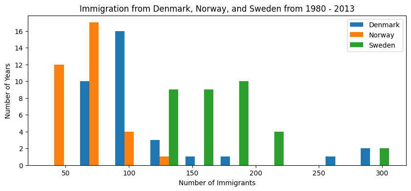

**Result:** Multiple histogram comparing Denmark, Norway, Sweden immigration

### Exercise: China and India Histogram

Here I examine the immigration distribution for **China and India** for the years **2000 to 2013**.

```
df = df_can.groupby(['Country'])[years].sum()
y = list(map(str, range(2000, 2014)))
df_ci = df.loc[['China', 'India'], y]
df_ci = df_ci.T

fig, ax = plt.subplots(figsize=(10, 4))
ax.hist(df_ci)
ax.set_title('Immigration from Denmark, Norway, and Sweden from 1980 - 2013')
ax.set_xlabel('Number of Immigrants')
ax.set_ylabel('Number of Years')
ax.legend(['China', 'India'])
plt.show()
```

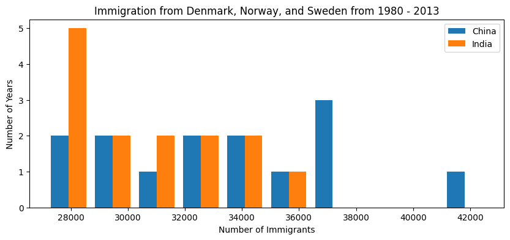

**Result:** Histogram comparing immigration from China and India

## 8. Pie Chart

```
fig, ax = plt.subplots()

# Pie on immigrants
ax.pie(total_immigrants[0:5], labels=years[0:5],
       colors=['gold', 'blue', 'lightgreen', 'coral', 'cyan'],
       autopct='%1.1f%%',
       explode=[0, 0, 0, 0, 0.1])  # Explode to highlight the smallest slice

ax.set_aspect('equal')  # Ensure pie is drawn as a circle

plt.title('Distribution of Immigrants from 1980 to 1985')
plt.show()
```

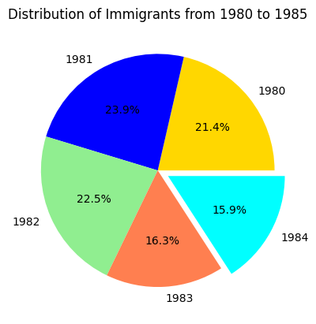

### Exercise: Continent-wise Pie Chart

Here I group the data by continent and visualize each continent's share of total immigration.

```
# Creating data for plotting pie
df_con = df_can.groupby('Continent')['Total'].sum().reset_index()
label = list(df_con.Continent)
label[3] = 'LAC'
label[4] = 'NA'
df_con
```

|  | Continent | Total |
| --- | --- | --- |
| 0 | Africa | 618948 |
| 1 | Asia | 3317794 |
| 2 | Europe | 1410947 |
| 3 | Latin America and the Caribbean | 765148 |
| 4 | Northern America | 241142 |
| 5 | Oceania | 55174 |

Next I plot the pie

```
fig, ax = plt.subplots(figsize=(10, 4))

# Pie on immigrants
ax.pie(df_con['Total'],
       colors=['gold', 'blue', 'lightgreen', 'coral', 'cyan', 'red'],
       autopct='%1.1f%%',
       pctdistance=1.25)

ax.set_aspect('equal') # Ensure pie is drawn as a circle

plt.title('Continent-wise distribution of immigrants')
ax.legend(label, bbox_to_anchor=(1, 0, 0.5, 1))
plt.show()
```

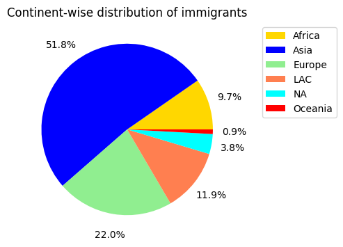

**Result:** Pie chart showing continent-wise distribution of immigrants

## 9. Subplotting

Subplotting lets us **display multiple plots in a single figure**. Here I create a line plot and a scatter plot side by side.

### Method 1: Using **`plt.subplots()`** with an array of axes

```
# Create a figure with two axes in a row
fig, axs = plt.subplots(1, 2, sharey=True)

# Plotting in first axes - the left one
axs[0].plot(total_immigrants)
axs[0].set_title("Line plot on immigrants")

# Plotting in second axes - the right one
axs[1].scatter(total_immigrants.index, total_immigrants)
axs[1].set_title("Scatter plot on immigrants")

axs[0].set_ylabel("Number of Immigrants")

# Adding a Title for the Overall Figure
fig.suptitle('Subplotting Example', fontsize=15)

# Adjust spacing between subplots
fig.tight_layout()
plt.show()
```

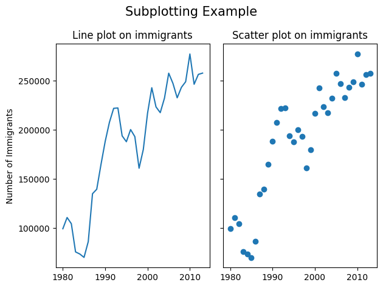

**Result:** Subplot with line plot (left) and scatter plot (right) sharing y-axis

### Method 2: Using **`add_subplot()`**

```
# Create a figure with Four axes - two rows, two columns
fig = plt.figure(figsize=(8, 4))

# Add the first subplot (top-left)
axs1 = fig.add_subplot(1, 2, 1)
axs1.plot(total_immigrants)
axs1.set_title("Line plot on immigrants")

# Add the second subplot (top-right)
axs2 = fig.add_subplot(1, 2, 2)
axs2.barh(total_immigrants.index, total_immigrants)  # Horizontal bar plot
axs2.set_title("Bar plot on immigrants")

# Adding a Title for the Overall Figure
fig.suptitle('Subplotting Example', fontsize=15)

# Adjust spacing between subplots
fig.tight_layout()
plt.show()
```

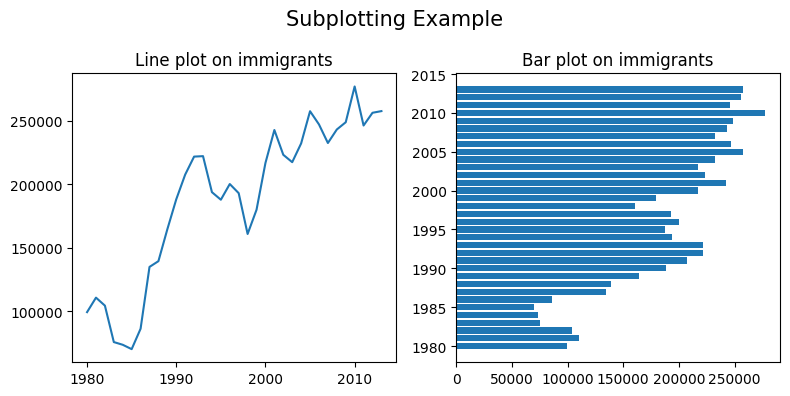

**Result:** Subplot with line plot (left) and horizontal bar plot (right)

### Exercise: 2×2 Subplot Grid

Now I combine four different plot types from this lab into a single 2×2 figure.

```
# Create a figure with Four axes - two rows, two columns
fig = plt.figure(figsize=(10, 10))

# Add the first subplot (top-left)
ax1 = fig.add_subplot(2, 2, 1)
ax1.plot(total_immigrants)
ax1.set_title('Plot 1 - Line Plot')

# Add the second subplot (top-right)
ax2 = fig.add_subplot(2, 2, 2)
ax2.scatter(total_immigrants.index, total_immigrants)
ax2.set_title('Plot 2 - Scatter plot')

# Add the third subplot (bottom-left)
ax3 = fig.add_subplot(2, 2, 3)
ax3.hist(df_dns)
ax3.set_title('Plot 3 - Histogram')
ax3.set_xlabel('Number of Immigrants')
ax3.set_ylabel('Number of Years')

# Add the fourth subplot (bottom-right)
ax4 = fig.add_subplot(2, 2, 4)
ax4.pie(total_immigrants[0:5], labels=years[0:5],
        colors=['gold', 'blue', 'lightgreen', 'coral', 'cyan'],
        autopct='%1.1f%%')
ax4.set_aspect('equal')
ax4.set_title('Plot 4 - Pie Chart')

# Adding a Title for the Overall Figure
fig.suptitle('Four Plots in a Figure Example', fontsize=15)

# Adjust spacing between subplots
fig.tight_layout()
plt.show()
```

[figure not shown]

**Result:** 2x2 subplot grid with line, scatter, histogram, and pie charts

That's the full walkthrough. I imported and cleaned the Canadian immigration dataset, then used Matplotlib to build and customize line, scatter, bar, histogram, pie, and subplot visualizations.